# 🎶 Coachella & Glamour Portfolio Optimizer

OPIM 5641 Final Project — Code Explanation, Results, and Automation

Author

Rama Akach

# Project Overview

The project also compares the optimized portfolio against a simple **buy-and-hold S&P 500 strategy** using SPY.

The system is designed to run automatically using GitHub Actions, meaning the model can update without manually running the code.

# Main Results Summary

**Note📊 Model Highlights**

|  | Metric | Value |
| --- | --- | --- |
| 0 | Run Date | 2026-10-31 |
| 1 | Model Mode | max_sharpe |
| 2 | Annualized Return | 76.99% |
| 3 | Annualized Risk | 14.53% |
| 4 | Sharpe Ratio | 4.955 |
| 5 | VIX Level | 19.42 |
| 6 | Paper Portfolio Value | $nan |
| 7 | SPY Paper Value | $nan |

## What these results mean

- **Annualized Return** estimates how much the portfolio could return over one year based on recent data.
- **Annualized Risk** measures volatility, or how much the portfolio value may move up and down.
- **Sharpe Ratio** measures return compared to risk. A higher Sharpe Ratio means stronger risk-adjusted performance.
- **VIX Level** measures market fear. Higher VIX means more market uncertainty.
- **Paper Portfolio Value** tracks a simulated $10,000 portfolio using the model.
- **SPY Paper Value** shows what would have happened if the same $10,000 was invested in the S&P 500 ETF.

# Dataset and Inputs

|  | Item | Value |
| --- | --- | --- |
| 0 | Data Source | Yahoo Finance |
| 1 | Benchmark | S&P 500 ETF (SPY) |
| 2 | Number of Stocks in Pool | 25 |
| 3 | Number of Stocks Selected | 8 |
| 4 | Sectors Used | Fashion, Beauty, Music, Healthcare, Tech |
| 5 | Sliding Window | 60 days |
| 6 | Minimum Weight | 5.00% |
| 7 | Maximum Weight | 40.00% |

## What this means

The model uses recent Yahoo Finance stock data. It compares the optimized portfolio against SPY because SPY represents the S&P 500 and works as a simple market baseline.

The model uses a sliding window, meaning it only looks at the most recent market data instead of using old historical data forever.

# Model Formulation

The optimizer uses two types of decision variables.

| Variable | Meaning |
| --- | --- |
| `Yᵢ` | Binary variable. Equals 1 if stock `i` is selected and 0 if it is not selected. |
| `Xᵢ` | Continuous variable. Represents the portfolio weight assigned to stock `i`. |

# Model Constraints

The portfolio must follow these constraints:

$$\sum X_i = 1$$

This means all portfolio weights must add up to 100%.

$$0.05Y_i \leq X_i \leq 0.40Y_i$$

This is the linking constraint. It connects the binary variable `Yᵢ` with the weight variable `Xᵢ`.

## What the linking constraint means

If a stock is selected:

```
Yᵢ = 1
```

Then:

```
0.05 ≤ Xᵢ ≤ 0.40
```

So the selected stock must receive at least 5% and at most 40%.

If a stock is not selected:

```
Yᵢ = 0
```

Then:

```
Xᵢ = 0
```

So the model cannot give money to stocks that were not selected.

# Objective Function

The model tries to maximize the Sharpe Ratio:

$$Sharpe = \frac{R_p - R_f}{\sigma_p}$$

| Symbol | Meaning |
| --- | --- |
| `Rₚ` | Expected portfolio return |
| `R_f` | Risk-free rate |
| `σₚ` | Portfolio risk |

## What this means

The Sharpe Ratio helps the model choose the portfolio that gives the best return for the amount of risk taken.

A portfolio with a high return but extremely high risk may not be ideal. The Sharpe Ratio balances both return and risk.

# Selected Portfolio Allocation

## What this means

# Portfolio vs S&P 500

|  | Metric | Optimized Portfolio | S&P 500 / SPY |
| --- | --- | --- | --- |
| 0 | Annualized Return | 76.99% | 9.15% |
| 1 | Annualized Risk | 14.53% | 11.03% |
| 2 | Sharpe Ratio | 4.955 | 0.377 |
| 3 | Max Drawdown | Not calculated | -3.38% |
| 4 | Paper Trading Value | $nan | $nan |

## What this means

This table compares the optimized model against a simple S&P 500 investment.

If the optimized portfolio has a higher Sharpe Ratio than SPY, then the model performed better on a risk-adjusted basis.

If the optimized portfolio has a higher return but also much higher risk, then the Sharpe Ratio helps decide whether the extra return is worth the extra risk.

# Efficient Frontier

The efficient frontier shows the tradeoff between expected return and risk.

Each point represents a possible portfolio. The chosen portfolio should be near the best risk-return tradeoff.

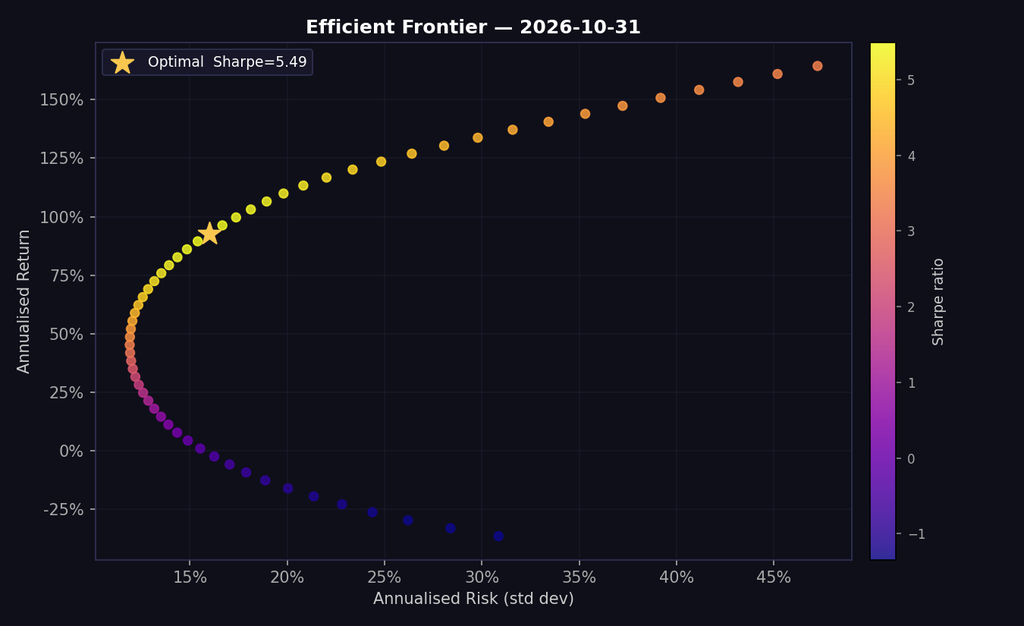

## What this chart means

- The x-axis shows risk.
- The y-axis shows return.
- Portfolios higher up have higher expected return.
- Portfolios further right have higher risk.
- The optimal point is the portfolio that gives the best risk-adjusted return.

# Allocation Pie Chart

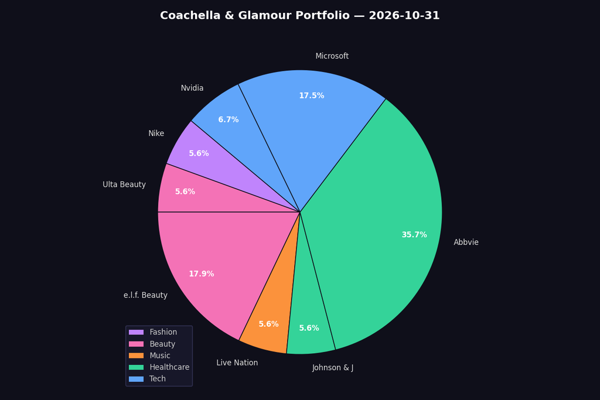

## What this chart means

This chart shows how the model divides money across the selected stocks.

A larger slice means the model allocated a larger part of the portfolio to that stock.

# Paper Trading Simulation

```
Preview of paper trading simulation (first 20 rows):
Dataset shape: (34, 4)
```

|  | date | portfolio_value | spy_value | daily_return |
| --- | --- | --- | --- | --- |
| 0 | 2026-09-15 | 9961.00 | 9954.13 | -0.003900 |
| 1 | 2026-09-16 | 9894.64 | 9910.24 | -0.006662 |
| 2 | 2026-09-17 | 9953.44 | 10022.61 | 0.005943 |
| 3 | 2026-09-18 | 9904.82 | 10035.50 | -0.004886 |
| 4 | 2026-09-21 | 10019.89 | 10191.10 | 0.011618 |
| 5 | 2026-09-22 | 10015.27 | 10189.52 | -0.000461 |
| 6 | 2026-09-23 | 10033.85 | 10116.14 | 0.001855 |
| 7 | 2026-09-24 | 10143.48 | 10107.84 | 0.010926 |
| 8 | 2026-09-25 | 10184.92 | 10162.78 | 0.004085 |
| 9 | 2026-09-28 | 10089.14 | 10087.15 | -0.009404 |
| 10 | 2026-09-29 | 10053.83 | 10068.57 | -0.003500 |
| 11 | 2026-09-30 | 10016.34 | 10047.89 | -0.003729 |
| 12 | 2026-10-01 | 9982.26 | 10065.81 | -0.003403 |
| 13 | 2026-10-02 | 9977.93 | 10140.25 | -0.000433 |
| 14 | 2026-10-05 | 9999.63 | 10208.63 | 0.002174 |
| 15 | 2026-10-06 | 10040.02 | 10264.76 | 0.004040 |
| 16 | 2026-10-07 | 10116.01 | 10240.12 | 0.007568 |
| 17 | 2026-10-08 | 10127.19 | 10196.77 | 0.001106 |
| 18 | 2026-10-09 | 10280.41 | 10257.90 | 0.015130 |
| 19 | 2026-10-12 | 10336.96 | 10251.71 | 0.005500 |

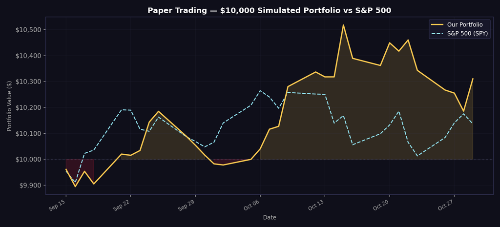

## What this means

This chart shows how a simulated **$10,000 portfolio** changes over time if the optimizer’s daily allocation decisions are followed.

- The yellow line represents the optimized portfolio.
- The dashed blue line represents the S&P 500 benchmark using SPY.
- When the yellow line rises, the portfolio is growing.
- When it falls, the portfolio is losing value.
- Comparing the yellow line to SPY shows whether the active optimization strategy is adding value compared to passive investing.

In this backtest, the portfolio changes each day because the model recalculates returns, risk, and optimal weights using the rolling 60-day window. This helps show whether the strategy performs well over time, not just on one single day.

# Weight History

```
Preview of daily allocation weight history (first 20 rows):
Dataset shape: (34, 29)
```

|  | date | ann_return | ann_risk | sharpe | LVMH | Ralph Lauren | Tapestry | Nike | Lululemon | Estee Lauder | ... | UnitedHealth | Johnson & J | Eli Lilly | Pfizer | Abbvie | Apple | Microsoft | Nvidia | Meta | Alphabet |
| --- | --- | --- | --- | --- | --- | --- | --- | --- | --- | --- | --- | --- | --- | --- | --- | --- | --- | --- | --- | --- | --- |
| 0 | 2026-09-15 | 0.906596 | 0.169896 | 5.0419 | 0.05 | 0.00 | 0.00 | 0.00 | 0.0 | 0.0 | ... | 0.0 | 0.105274 | 0.0 | 0.000000 | 0.248190 | 0.0 | 0.174350 | 0.000000 | 0.083074 | 0.0 |
| 1 | 2026-09-16 | 0.869769 | 0.169450 | 4.8378 | 0.00 | 0.05 | 0.00 | 0.00 | 0.0 | 0.0 | ... | 0.0 | 0.255619 | 0.0 | 0.000000 | 0.058417 | 0.0 | 0.192396 | 0.000000 | 0.106422 | 0.0 |
| 2 | 2026-09-17 | 0.827039 | 0.177842 | 4.3693 | 0.05 | 0.00 | 0.00 | 0.00 | 0.0 | 0.0 | ... | 0.0 | 0.211451 | 0.0 | 0.000000 | 0.063021 | 0.0 | 0.188887 | 0.000000 | 0.129763 | 0.0 |
| 3 | 2026-09-18 | 0.835353 | 0.175049 | 4.4865 | 0.05 | 0.00 | 0.00 | 0.00 | 0.0 | 0.0 | ... | 0.0 | 0.194994 | 0.0 | 0.000000 | 0.068926 | 0.0 | 0.219439 | 0.000000 | 0.142447 | 0.0 |
| 4 | 2026-09-21 | 0.819845 | 0.164267 | 4.6865 | 0.05 | 0.00 | 0.00 | 0.00 | 0.0 | 0.0 | ... | 0.0 | 0.153716 | 0.0 | 0.114861 | 0.000000 | 0.0 | 0.214001 | 0.147290 | 0.000000 | 0.0 |
| 5 | 2026-09-22 | 0.888078 | 0.196315 | 4.2691 | 0.05 | 0.00 | 0.00 | 0.05 | 0.0 | 0.0 | ... | 0.0 | 0.050000 | 0.0 | 0.180261 | 0.000000 | 0.0 | 0.239054 | 0.000000 | 0.164517 | 0.0 |
| 6 | 2026-09-23 | 0.887308 | 0.180585 | 4.6366 | 0.00 | 0.05 | 0.00 | 0.00 | 0.0 | 0.0 | ... | 0.0 | 0.050000 | 0.0 | 0.223657 | 0.000000 | 0.0 | 0.233687 | 0.000000 | 0.149597 | 0.0 |
| 7 | 2026-09-24 | 0.829425 | 0.167560 | 4.6516 | 0.00 | 0.05 | 0.00 | 0.00 | 0.0 | 0.0 | ... | 0.0 | 0.050000 | 0.0 | 0.291541 | 0.000000 | 0.0 | 0.212391 | 0.000000 | 0.146069 | 0.0 |
| 8 | 2026-09-25 | 0.758342 | 0.164054 | 4.3177 | 0.05 | 0.00 | 0.00 | 0.00 | 0.0 | 0.0 | ... | 0.0 | 0.050000 | 0.0 | 0.311431 | 0.000000 | 0.0 | 0.194027 | 0.000000 | 0.144542 | 0.0 |
| 9 | 2026-09-28 | 0.738978 | 0.172970 | 3.9832 | 0.05 | 0.05 | 0.00 | 0.00 | 0.0 | 0.0 | ... | 0.0 | 0.050000 | 0.0 | 0.279950 | 0.000000 | 0.0 | 0.217464 | 0.000000 | 0.152586 | 0.0 |
| 10 | 2026-09-29 | 0.696029 | 0.142203 | 4.5430 | 0.00 | 0.05 | 0.00 | 0.05 | 0.0 | 0.0 | ... | 0.0 | 0.050000 | 0.0 | 0.390949 | 0.000000 | 0.0 | 0.132017 | 0.127034 | 0.000000 | 0.0 |
| 11 | 2026-09-30 | 0.625949 | 0.139645 | 4.1244 | 0.05 | 0.05 | 0.00 | 0.00 | 0.0 | 0.0 | ... | 0.0 | 0.050000 | 0.0 | 0.400000 | 0.000000 | 0.0 | 0.145300 | 0.104700 | 0.000000 | 0.0 |
| 12 | 2026-10-01 | 0.694470 | 0.149274 | 4.3174 | 0.00 | 0.05 | 0.05 | 0.00 | 0.0 | 0.0 | ... | 0.0 | 0.050000 | 0.0 | 0.373995 | 0.000000 | 0.0 | 0.193389 | 0.000000 | 0.082616 | 0.0 |
| 13 | 2026-10-02 | 0.661312 | 0.155646 | 3.9276 | 0.00 | 0.05 | 0.05 | 0.00 | 0.0 | 0.0 | ... | 0.0 | 0.000000 | 0.0 | 0.318023 | 0.050000 | 0.0 | 0.188719 | 0.119140 | 0.000000 | 0.0 |
| 14 | 2026-10-05 | 0.669776 | 0.163984 | 3.7795 | 0.00 | 0.05 | 0.05 | 0.00 | 0.0 | 0.0 | ... | 0.0 | 0.000000 | 0.0 | 0.300416 | 0.050000 | 0.0 | 0.220268 | 0.093712 | 0.000000 | 0.0 |
| 15 | 2026-10-06 | 0.721073 | 0.166394 | 4.0330 | 0.00 | 0.05 | 0.05 | 0.00 | 0.0 | 0.0 | ... | 0.0 | 0.000000 | 0.0 | 0.067305 | 0.156507 | 0.0 | 0.225881 | 0.202199 | 0.000000 | 0.0 |
| 16 | 2026-10-07 | 0.763729 | 0.163990 | 4.3523 | 0.00 | 0.05 | 0.05 | 0.00 | 0.0 | 0.0 | ... | 0.0 | 0.000000 | 0.0 | 0.084873 | 0.187248 | 0.0 | 0.237810 | 0.123833 | 0.000000 | 0.0 |
| 17 | 2026-10-08 | 0.731999 | 0.162584 | 4.1948 | 0.00 | 0.05 | 0.00 | 0.05 | 0.0 | 0.0 | ... | 0.0 | 0.000000 | 0.0 | 0.050000 | 0.220375 | 0.0 | 0.231767 | 0.111865 | 0.000000 | 0.0 |
| 18 | 2026-10-09 | 0.734721 | 0.176055 | 3.8892 | 0.00 | 0.05 | 0.00 | 0.05 | 0.0 | 0.0 | ... | 0.0 | 0.000000 | 0.0 | 0.050000 | 0.173762 | 0.0 | 0.239846 | 0.105322 | 0.000000 | 0.0 |
| 19 | 2026-10-12 | 0.790593 | 0.162960 | 4.5446 | 0.00 | 0.05 | 0.05 | 0.00 | 0.0 | 0.0 | ... | 0.0 | 0.000000 | 0.0 | 0.073233 | 0.184600 | 0.0 | 0.224233 | 0.127895 | 0.000000 | 0.0 |

20 rows × 29 columns

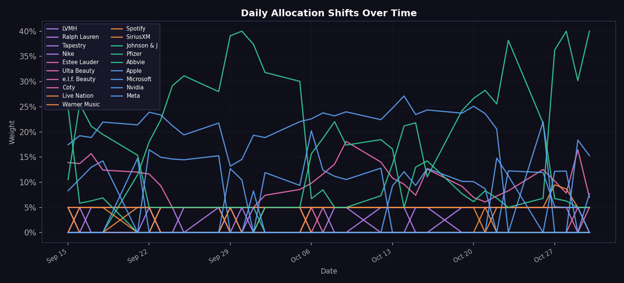

## What this means

This chart shows how the model changes the stock allocation weights over time.

Each line represents one stock’s portfolio weight. When a line rises, the optimizer is giving that stock more weight. When a line falls to zero, the stock was removed from the selected portfolio for that day.

This is important because it proves the portfolio is not static. The model is rebalancing daily based on updated market data from the sliding 60-day window.

The chart also shows the linking constraints in action:

- selected stocks receive at least 5%
- no selected stock exceeds 40%
- unselected stocks receive 0%

## Overall, this chart shows how the optimizer actively adjusts the portfolio as market conditions change.

# Golden Cross Signals

## What this means

Golden Cross signals are used as a momentum indicator.

| Signal | Meaning |
| --- | --- |
| Bullish | Short-term trend is stronger than long-term trend |
| Bearish | Short-term trend is weaker than long-term trend |
| Neutral | No clear trend signal |

The model calculates this using a 10-day moving average and a 30-day moving average.

# VIX Fear Index Logic

|  | Item | Value |
| --- | --- | --- |
| 0 | Current VIX | 19.42 |
| 1 | VIX Threshold | 28 |
| 2 | Model Mode | max_sharpe |

## What this means

The model uses VIX as a fear-index signal.

If:

```
VIX > 28
```

the model switches to minimum-variance mode. This means it focuses more on reducing risk.

If:

```
VIX ≤ 28
```

the model uses maximum-Sharpe mode. This means it focuses on the best return per unit of risk.

# Optimizer Code Explanation

This section explains the main parts of `optimizer.py`.

## 1. Import Libraries

```python
import numpy as np
import pandas as pd
import matplotlib.pyplot as plt
from scipy.optimize import minimize, Bounds
import yfinance as yf
from datetime import datetime, timedelta
import json, os
```

### What this does

- `numpy` handles numerical calculations.
- `pandas` handles tables and return calculations.
- `matplotlib` creates charts.
- `scipy.optimize` solves the portfolio optimization problem.
- `yfinance` downloads market data.
- `json` saves dashboard results.
- `os` creates folders and manages file paths.

## 2. Define Stock Pool

```python
STOCKS = {
    "Apple": ("AAPL", "Tech"),
    "Nike": ("NKE", "Fashion"),
    "Spotify": ("SPOT", "Music")
}
```

### What this does

The full script stores 25 companies. Each stock has:

- company name
- ticker symbol
- sector

This lets the model choose from a larger pool and maintain sector diversification.

## 3. Set Model Parameters

```python
N_SELECT = 10
MIN_WEIGHT = 0.05
MAX_WEIGHT = 0.40
WINDOW_DAYS = 60
RESULTS_DIR = "results"
```

### What this does

These settings control the model:

[output not shown]

## 4. Fetch Market Data

```python
tickers = [v[0] for v in STOCKS.values()] + ["SPY", "^VIX"]

raw = yf.download(
    tickers,
    start=start.strftime("%Y-%m-%d"),
    end=end.strftime("%Y-%m-%d"),
    interval="1d",
    auto_adjust=True,
    progress=False
)
```

### What this does

This downloads daily price data for:

- all stocks in the pool
- SPY as the S&P 500 benchmark
- VIX as the fear index

The model uses this data to calculate returns and risk.

## 5. Calculate Returns

```python
returns = stock_prices.pct_change().dropna()
mu = returns.mean()
cov = returns.cov()
```

### What this does

This converts stock prices into daily returns.

Then it calculates:

- `mu`: average daily return for each stock
- `cov`: covariance matrix showing how stocks move together

These are needed for Modern Portfolio Theory.

## 6. Portfolio Statistics

```python
ret = np.dot(w, mu) * 252
risk = np.sqrt(w @ cov @ w * 252)
```

### What this does

This calculates:

- annualized portfolio return
- annualized portfolio risk

The number `252` is used because there are about 252 trading days in a year.

## 7. Optimization Objective

```python
def obj(w):
    ret = np.dot(w, mu_s) * 252
    risk = np.sqrt(w @ cov_s @ w * 252)
    return -(ret - 0.05) / risk
```

### What this does

The optimizer minimizes the negative Sharpe Ratio.

This is the same as maximizing the Sharpe Ratio.

## 8. Constraints and Bounds

```python
constraints = [{"type": "eq", "fun": lambda w: np.sum(w) - 1}]
bounds = Bounds(min_w, max_w)
```

### What this does

The constraint forces the portfolio weights to sum to 1.

The bounds force each selected stock to stay between the minimum and maximum weight limits.

## 9. Stock Selection Logic

```python
chosen.extend(pool_sorted[:2])
```

### What this does

The model begins by selecting strong candidates from each sector.

This supports diversification because it prevents the optimizer from choosing all stocks from one sector.

## 10. Local Search Improvement

```python
for drop in sector_in_chosen:
    for add in sector_not_chosen:
        candidate = [i if i != drop else add for i in best_subset]
```

### What this does

After the first selection, the model tries swaps.

It removes one stock and adds another stock from the same sector to see if Sharpe Ratio improves.

This improves the final selected portfolio.

## 11. S&P 500 Comparison

```python
spy_ret = (spy.iloc[-1] / spy.iloc[0]) - 1
spy_vol = spy.pct_change().dropna().std() * np.sqrt(252)
```

### What this does

This calculates SPY return, risk, drawdown, and Sharpe Ratio.

This gives a baseline to compare the optimized portfolio against.

## 12. Paper Trading Tracker

```python
port_val *= (1 + port_daily)
```

### What this does

This updates the simulated portfolio value each day.

The portfolio starts at $10,000 and changes based on the daily return of the selected stocks.

## 13. Save JSON Output

```python
with open("results/latest.json", "w") as f:
    json.dump(summary, f, indent=2)
```

### What this does

This saves the latest model results into a JSON file.

The dashboard reads this file to display updated results.

## 14. Save Charts

```python
plot_efficient_frontier(...)
plot_allocation_pie(...)
plot_paper_trading(...)
plot_weight_history(...)
```

### What this does

These functions create visual outputs for:

- efficient frontier
- portfolio allocation
- paper trading performance
- allocation changes over time

These charts make the model easier to understand.

# GitHub Actions Workflow Explanation

This section explains the `.yml` workflow file.

## Workflow Purpose

The workflow automatically runs the optimizer on GitHub.

Instead of manually running the code, GitHub Actions runs it on a schedule and updates the results folder.

## 1. Workflow Name

```yaml
name: Daily Portfolio Update
```

### What this does

This gives the workflow a readable name inside the GitHub Actions tab.

## 2. Schedule

```yaml
on:
  schedule:
    - cron: '55 20 * * 1-5'
  workflow_dispatch:
```

### What this does

This runs the workflow Monday through Friday.

It also allows the workflow to be run manually using the **Run workflow** button.

## 3. Runner

```yaml
runs-on: ubuntu-latest
```

### What this does

GitHub creates a temporary Linux computer to run the project.

This is why file names must match exactly, including capitalization.

## 4. Permissions

```yaml
permissions:
  contents: write
```

### What this does

This allows the workflow to push updated result files back into the repository.

Without this permission, GitHub Actions could run the script but might not be able to save updates.

## 5. Checkout Repository

```yaml
- name: Checkout repository
  uses: actions/checkout@v4
```

### What this does

This downloads the repository files into the GitHub Actions runner.

## 6. Set Up Python

```yaml
- name: Set up Python 3.10
  uses: actions/setup-python@v4
  with:
    python-version: '3.10'
```

### What this does

This installs Python 3.10 in the GitHub runner.

## 7. Install Dependencies

```yaml
- name: Install dependencies
  run: |
    python -m pip install --upgrade pip
    pip install -r requirements.txt
```

### What this does

This installs all required Python packages listed in `requirements.txt`.

Examples include:

- pandas
- numpy
- scipy
- yfinance
- matplotlib

## 8. Run Optimizer

```yaml
- name: Run Portfolio Optimizer
  run: python optimizer.py
```

### What this does

This runs the main optimization script.

It downloads data, runs the model, creates charts, saves CSV files, and updates `latest.json`.

## 9. Commit and Push Results

```yaml
git add results/
git commit -m "Daily update"
git pull --rebase origin main
git push
```

### What this does

This saves the newly generated results back into GitHub.

This is what makes the dashboard update over time.

# Output Files Explained

|  | File | Purpose |
| --- | --- | --- |
| 0 | results/latest.json | Stores latest model results for the dashboard |
| 1 | results/REPORT.md | Markdown summary report generated by optimizer |
| 2 | results/efficient_frontier.png | Shows risk-return efficient frontier |
| 3 | results/allocation_pie.png | Shows portfolio allocation weights |
| 4 | results/paper_trading.csv | Tracks simulated $10,000 portfolio value |
| 5 | results/weight_history.csv | Tracks how weights change over time |
| 6 | Dashboard.html | Live-style HTML dashboard |
| 7 | portfolio_dashboard.html | Quarto explanation dashboard/report |

# Final Interpretation

The outputs from the optimizer show how the portfolio adapts to recent market conditions using Modern Portfolio Theory and momentum signals.

The efficient frontier chart confirms that the selected portfolio lies near the best risk-return tradeoff among available combinations, while the allocation pie chart shows how the optimizer distributes investment across sectors to maintain diversification.

The paper trading simulation tracks how a $10,000 portfolio would perform if the strategy were followed over time. Comparing this simulated portfolio against SPY helps evaluate whether the optimization approach adds value beyond passive investing.

The Golden Cross indicators provide short-term momentum signals that support timing decisions, while the VIX fear index allows the model to automatically switch between return-focused mode (max-Sharpe) and risk-reduction mode (minimum-variance) depending on market uncertainty.

Because the optimizer runs automatically through GitHub Actions using updated Yahoo Finance data, the system behaves like a live decision-support tool rather than a one-time analysis. This demonstrates how portfolio optimization models can be used in practice to support ongoing investment allocation decisions.